# Lab 1 code

This notebook contains the code, the figures and the answers to the questions of the lab. The run-by-run record (hypothesis, change, validation result, conclusion) is in `logbook.md`.

## 1. Initialization

In this section we import the proper libraries and define a seed

```python
import copy, time, random
import numpy as np, pandas as pd
import matplotlib.pyplot as plt
import torch, torch.nn as nn, torch.optim as optim
from IPython.display import display
from torch.utils.data import DataLoader, TensorDataset
from sklearn.model_selection import train_test_split
from sklearn.preprocessing import LabelEncoder, StandardScaler, RobustScaler, FunctionTransformer
from sklearn.pipeline import Pipeline
from sklearn.metrics import classification_report, confusion_matrix, f1_score, recall_score, ConfusionMatrixDisplay

SEED = 42
DATA_PATH = "dataset_lab_1.csv"
device = torch.device("cuda" if torch.cuda.is_available() else "cpu")
print(device)

def set_seed(seed):
    # The same seed must always produce the same run.
    random.seed(seed); np.random.seed(seed); torch.manual_seed(seed)
    torch.cuda.manual_seed_all(seed)
    torch.backends.cudnn.deterministic = True
    torch.backends.cudnn.benchmark = False

def load_raw(csv_path):
    # Read the csv once. Some column names start with a space.
    df = pd.read_csv(csv_path)
    df.columns = df.columns.str.strip()
    return df

def issue_masks(df):
    # One mask per kind of bad row, so that the analysis and prepare_data
    # never disagree on what has to be removed.
    num = df.drop(columns=["Label"])
    num_box = num.replace([np.inf, -np.inf], np.nan)
    return dict(nan=df.isna().any(axis=1),
                inf=np.isinf(num).any(axis=1),
                negative=(num_box < 0).any(axis=1))
```

```
cuda
```

## 2. Task 1: Preprocessing

Before training anything we look at the raw data, clean it, split it and decide how to scale the features. All these steps are implemented in `prepare_data`, so that every experiment of the lab starts from exactly the same data and the only thing that changes between experiments is the model. The `drop_port` and `drop_duplicates` flags allow the following tasks to obtain the dataset without the destination port and/or without deduplication.

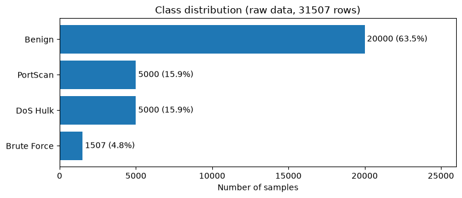

```
Missing, infinite and negative values per column:
                 NaN  inf  negative
Flow Duration     0    0         2
Flow IAT Mean     0    0         2
Flow Bytes/s     20    7         2
Flow Packets/s    0   27         2
```

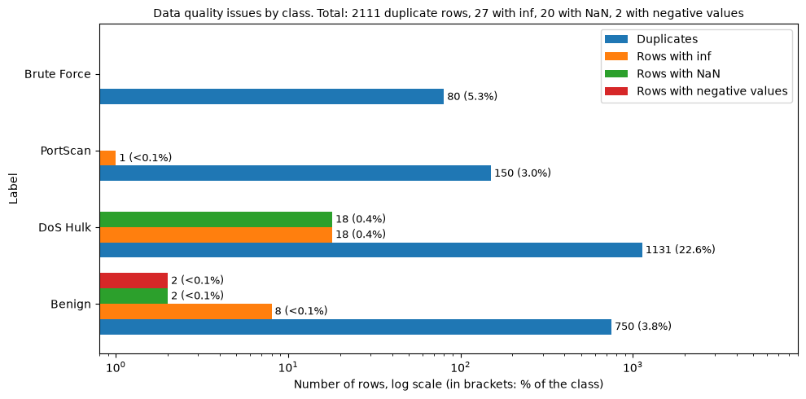

```python
# Look at the raw data first. Nothing is modified in this cell.
raw = load_raw(DATA_PATH)

# Class balance: number of rows per class, smallest class at the bottom.
counts_raw = raw["Label"].value_counts()
counts = counts_raw.sort_values()
perc = counts / counts.sum() * 100

fig, ax = plt.subplots(figsize=(8, 3.5))
ax.barh(counts.index, counts.values)
for i, (c, p) in enumerate(zip(counts.values, perc.values)):
    ax.text(c, i, f" {c} ({p:.1f}%)", va="center")
ax.set_xlim(0, counts.max() * 1.3)
ax.set_xlabel("Number of samples")
ax.set_title(f"Class distribution (raw data, {len(raw)} rows)")
plt.tight_layout()
plt.show()
plt.close()

# Features only. Infinite values become NaN so that the values can be plotted.
num = raw.drop(columns=["Label"])
num_box = num.replace([np.inf, -np.inf], np.nan)

# Count missing (NaN), infinite and negative values in each column.
# All features are counts, sizes, durations, rates or ports, so they cannot be negative.
bad_cols = pd.DataFrame({"NaN": num.isna().sum(),
                         "inf": np.isinf(num).sum(),
                         "negative": (num_box < 0).sum()})
bad_cols = bad_cols[(bad_cols > 0).any(axis=1)]

print("Missing, infinite and negative values per column:\n", bad_cols)

# Rows with a problem: duplicate, infinite value, missing value or negative value.
masks = issue_masks(raw)
dup_mask = raw.duplicated()
inf_mask, nan_mask, neg_mask = masks["inf"], masks["nan"], masks["negative"]

# Count each problem per class.
issues = pd.DataFrame({
    "Duplicates": raw[dup_mask]["Label"].value_counts(),
    "Rows with inf": raw[inf_mask]["Label"].value_counts(),
    "Rows with NaN": raw[nan_mask]["Label"].value_counts(),
    "Rows with negative values": raw[neg_mask]["Label"].value_counts(),
}).reindex(counts_raw.index).fillna(0).astype(int)
issues_perc = issues.div(counts_raw, axis=0) * 100

# One bar group per class, one bar per problem.
# Log x-axis: a few rows stay visible next to thousands of duplicates.
ax = issues.plot.barh(figsize=(10, 5), width=0.8)
for cont, col in zip(ax.containers, issues.columns):
    labels = ["" if n == 0 else (f" {n} (<0.1%)" if p < 0.1 else f" {n} ({p:.1f}%)")
              for n, p in zip(issues[col], issues_perc[col])]
    ax.bar_label(cont, labels=labels, fontsize=9)
ax.set_xscale("log")
ax.set_xlim(0.8, issues.values.max() * 8)
ax.set_xlabel("Number of rows, log scale (in brackets: % of the class)")
ax.set_title(f"Data quality issues by class. Total: {dup_mask.sum()} duplicate rows, "
             f"{inf_mask.sum()} with inf, {nan_mask.sum()} with NaN, {neg_mask.sum()} with negative values",
             fontsize=10)
ax.legend(loc="upper right")
plt.tight_layout()
plt.show()
plt.close()
```

```
Constant columns: none
Identical pairs of columns: [('Fwd PSH Flags', 'SYN Flag Count'), ('Subflow Fwd Packets', 'Total Fwd Packets')]
```

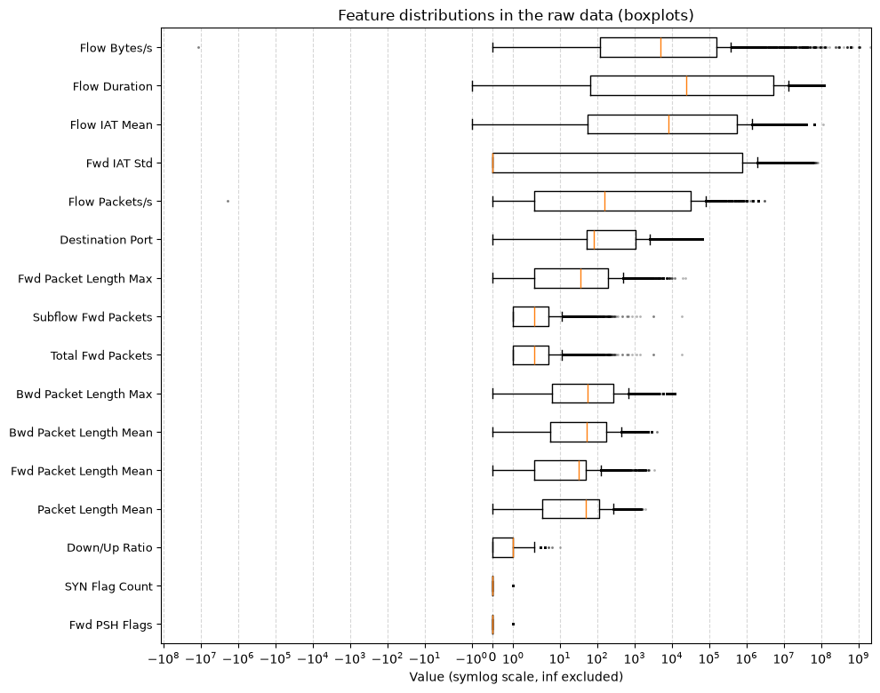

```python
# Look for useless features: columns with a single value, and pairs of identical columns.
const_cols = [c for c in num_box.columns if num_box[c].nunique() <= 1]
cols = num_box.columns
identical = [(a, b) for i, a in enumerate(cols) for b in cols[i + 1:] if num_box[a].equals(num_box[b])]
print("Constant columns:", const_cols if const_cols else "none")
print("Identical pairs of columns:", identical if identical else "none")

# Boxplot of every feature on a log-like scale (inf removed).
# The box is the central 50% of the values, the dots are the outliers.
order = num_box.max().sort_values().index

fig, ax = plt.subplots(figsize=(10, 0.4 * len(order) + 1.5))
ax.boxplot([num_box[c].dropna() for c in order], orientation="horizontal",
           flierprops=dict(marker=".", markersize=2, alpha=0.3))
ax.set_yticks(range(1, len(order) + 1))
ax.set_yticklabels(order, fontsize=9)
ax.set_xscale("symlog")
ax.set_xlabel("Value (symlog scale, inf excluded)")
ax.set_title("Feature distributions in the raw data (boxplots)")
ax.grid(axis="x", linestyle="--", alpha=0.5)
plt.tight_layout()
plt.show()
plt.close()
```

### 2.1. Cleaning

*Q: How many samples do you have before and after your cleaning?*

31507 rows before cleaning and 29384 after: 2123 rows (6.7%) are removed and 93.3% of the data is kept. The steps remove very different amounts, which is why `prepare_data` reports them one by one:

| Step | Rows removed |
| --- | --- |
| inf -> NaN, then rows with NaN | 27 |
| negative values | 2 |
| duplicate rows | 2094 |

The inspection also shows that there is no constant column, but two pairs of features are identical (`Fwd PSH Flags` = `SYN Flag Count` and `Subflow Fwd Packets` = `Total Fwd Packets`): one column of each pair carries no additional information. We keep them, because duplicated inputs do not harm a feed-forward network and the column layout stays identical to the data used in Task 3.

The labels are then encoded as integers, the data is split 70/15/15 with stratification, and the features are transformed with `log1p` + `StandardScaler` fitted on the training set only (the choice is justified in 2.5). `prepare_data` returns both the transformed arrays (`X`) and the untouched ones (`Xraw`), which are needed for the "no scaling" experiment of Task 2B and for the counterfactual test of Task 3.

```python
def prepare_data(csv_path, drop_port=False, drop_duplicates=True, seed=SEED):
    # Read the csv and keep the class counts after every step, to report how many rows are removed.
    df = load_raw(csv_path)
    counts = {"raw": df["Label"].value_counts()}

    # 1) Drop the rows with an infinite or a missing value.
    masks = issue_masks(df)
    df = df[~(masks["inf"] | masks["nan"])]
    counts["after_nan"] = df["Label"].value_counts()

    # 2) Drop the rows with negative values.
    df = df[~issue_masks(df)["negative"]]
    counts["after_negatives"] = df["Label"].value_counts()

    # 3) Optional: drop the destination port.
    if drop_port:
        df = df.drop(columns=["Destination Port"])
    # 4) Optional: drop duplicate rows. Done last, because dropping the port creates new duplicates.
    if drop_duplicates:
        df = df.drop_duplicates()

    counts["after_clean"] = df["Label"].value_counts()

    # Encode the labels as integers.
    le = LabelEncoder()
    y = le.fit_transform(df["Label"].values)
    feature_names = [c for c in df.columns if c != "Label"]
    X = df[feature_names].values

    # Split 70% train, 15% validation, 15% test. Stratify keeps the class proportions.
    Xtr, Xtmp, ytr, ytmp = train_test_split(X, y, test_size=0.3, random_state=seed, stratify=y)
    Xva, Xte, yva, yte = train_test_split(Xtmp, ytmp, test_size=0.5, random_state=seed, stratify=ytmp)

    # log1p has no parameters, so it is safe on every split.
    # The StandardScaler is fitted on the training data only, to avoid leakage.
    scaler = Pipeline([
        ("log1p", FunctionTransformer(np.log1p)),
        ("standardize", StandardScaler()),
    ]).fit(Xtr)

    # Return the raw arrays (used by the no-scaling test) and the scaled ones.
    raw = dict(train=Xtr, val=Xva, test=Xte)
    return dict(
        Xraw=raw,
        X={k: scaler.transform(v) for k, v in raw.items()},
        y=dict(train=ytr, val=yva, test=yte),
        class_names=list(le.classes_), feature_names=feature_names,
        scaler=scaler, counts=pd.DataFrame(counts))
```

Concerning Task 3, we clean the dataset without optional parameters to use the full cleaning stages

```python
D = prepare_data(DATA_PATH)

# Readable column names and class counts after each cleaning step.
step_labels = {"raw": "Raw data", "after_nan": "After inf/NaN",
               "after_negatives": "After negatives", "after_clean": "After duplicates"}
cleaning = D["counts"].rename(columns=step_labels).fillna(0).astype(int)
cleaning.loc["TOTAL"] = cleaning.sum()

print('Data before and after pre processing (class counts after each step)')
display(cleaning)

# Difference between consecutive steps = rows removed.
total = cleaning.loc["TOTAL"]
removed = (total.shift(1) - total).dropna().astype(int)
print('\nRows removed by each step')
display(removed.to_frame("Rows removed"))

print('\nDistribution of samples across classes')
# Number of samples in each split.
split_summary = pd.DataFrame(
    [{"Split": k.capitalize(), "Samples": len(v)} for k, v in D["y"].items()]
)
display(split_summary)
```

```
Data before and after pre processing (class counts after each step)
```

| Label | Raw data | After inf/NaN | After negatives | After duplicates |
| --- | --- | --- | --- | --- |
| Benign | 20000 | 19992 | 19990 | 19240 |
| Brute Force | 1507 | 1507 | 1507 | 1427 |
| DoS Hulk | 5000 | 4982 | 4982 | 3868 |
| PortScan | 5000 | 4999 | 4999 | 4849 |
| TOTAL | 31507 | 31480 | 31478 | 29384 |

```
Rows removed by each step
```

|  | Rows removed |
| --- | --- |
| After inf/NaN | 27 |
| After negatives | 2 |
| After duplicates | 2094 |

```
Distribution of samples across classes
```

|  | Split | Samples |
| --- | --- | --- |
| 0 | Train | 20568 |
| 1 | Val | 4408 |
| 2 | Test | 4408 |

### 2.2. Class balance and feature distributions after cleaning

29384 flows are left (from 31507): Brute Force stays the smallest class with 1427 flows (4.9%), so the imbalance is unchanged and the stratified split is still needed. The histograms plot every feature of the cleaned training set with a logarithmic y-axis, otherwise the few values in the tails would not be visible. The long right tails visible in the raw boxplots are still there: this is exactly what `log1p` has to compress.

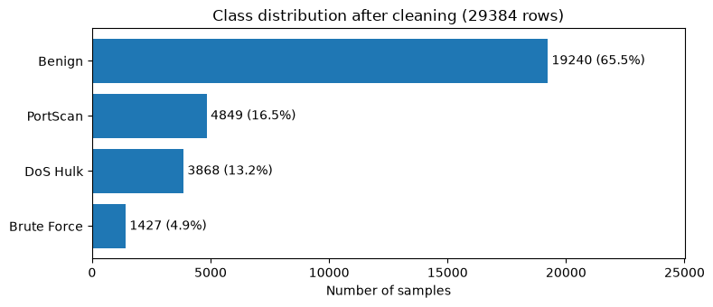

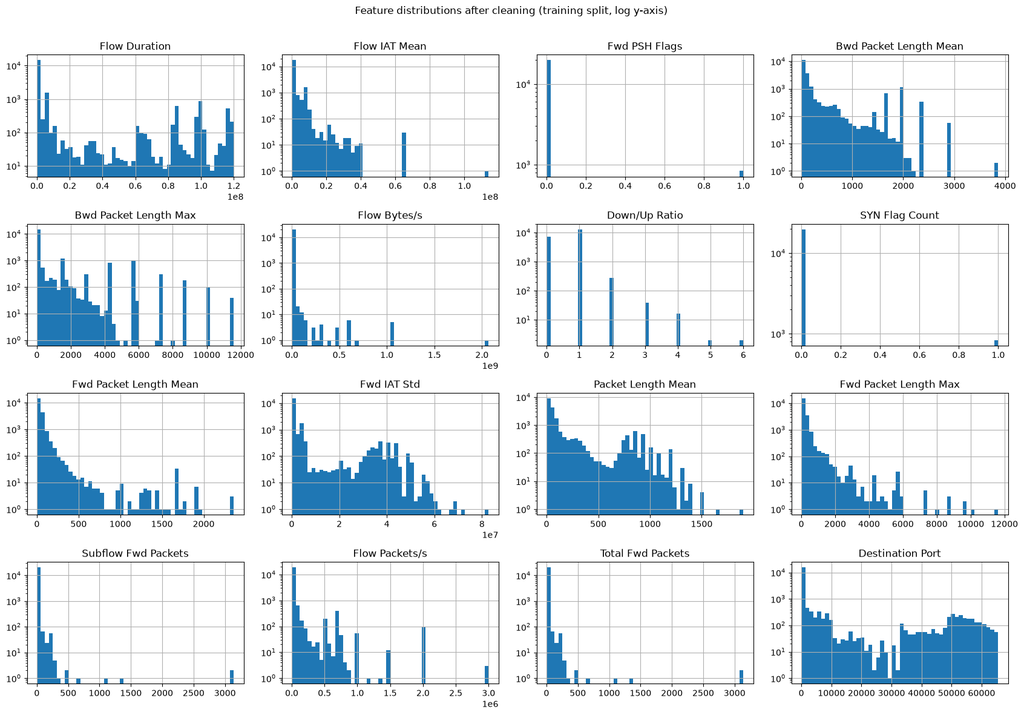

```python
# Class balance after cleaning.
counts_clean = D["counts"]["after_clean"].sort_values()
perc = counts_clean / counts_clean.sum() * 100

fig, ax = plt.subplots(figsize=(8, 3.5))
ax.barh(counts_clean.index, counts_clean.values)
for i, (c, p) in enumerate(zip(counts_clean.values, perc.values)):
    ax.text(c, i, f" {c} ({p:.1f}%)", va="center")
ax.set_xlim(0, counts_clean.max() * 1.3)
ax.set_xlabel("Number of samples")
ax.set_title(f"Class distribution after cleaning ({counts_clean.sum()} rows)")
plt.tight_layout()
plt.show()
plt.close()

# One histogram per feature on the cleaned training set.
# Log y-axis, otherwise the tails are invisible.
pd.DataFrame(D["Xraw"]["train"], columns=D["feature_names"]).hist(bins=50, figsize=(17, 12), log=True)
plt.suptitle("Feature distributions after cleaning (training split, log y-axis)")
plt.tight_layout(rect=[0, 0, 1, 0.97])
plt.show()
plt.close()
```

### 2.3. Stratified vs random split

Since Brute Force is less than 5% of the data, a random split could concentrate a sizeable share of it in a single partition. Both calls to `train_test_split` are therefore stratified, so every partition keeps the class proportions of the whole dataset. To show that it makes a difference, the same split (same seed) is repeated without `stratify` and the class shares are compared. Both panels use the same seed and the same proportions as the split used in the rest of the lab; `split_proportions` re-draws the split from the labels, so the left panel shows the same proportions, not literally the same rows.

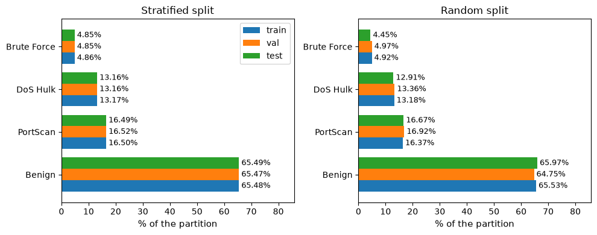

```python
# Compare the same split with and without stratification.
class_names_arr = np.array(D["class_names"])
# The three splits together rebuild the labels of the cleaned dataset.
y_all = np.concatenate([D["y"]["train"], D["y"]["val"], D["y"]["test"]])


# Same split, same seed. stratify is None when stratified is False.
def split_proportions(stratified):
    y_tr, y_tmp = train_test_split(y_all, test_size=0.3, random_state=SEED,
                                   stratify=y_all if stratified else None)
    y_va, y_te = train_test_split(y_tmp, test_size=0.5, random_state=SEED,
                                  stratify=y_tmp if stratified else None)
    return pd.DataFrame({
        name: pd.Series(class_names_arr[yy]).value_counts(normalize=True) * 100
        for name, yy in [("train", y_tr), ("val", y_va), ("test", y_te)]
    })


# Left: the stratified split used in the lab. Right: a random split, for comparison.
fig, axes = plt.subplots(1, 2, figsize=(10, 4), sharex=True)
for ax, stratified, title in [(axes[0], True, "Stratified split"), (axes[1], False, "Random split")]:
    shares = split_proportions(stratified)
    # Percentage of each class in train, validation and test.
    shares.plot.barh(ax=ax, legend=(ax is axes[0]), width=0.8)
    for cont in ax.containers:
        ax.bar_label(cont, fmt=" %.2f%%", fontsize=9)
    ax.set_xlabel("% of the partition", fontsize=11)
    ax.set_ylabel("")
    ax.set_title(title, fontsize=12)
    ax.tick_params(labelsize=10)
axes[0].set_xlim(0, shares.values.max() * 1.3)
plt.tight_layout()
plt.show()
plt.close()
```

*Q: Given the class balance, should the split be stratified? Why? Where did you fit the scaler, and what goes wrong if you fit it on all the data?*

Yes: Brute Force is 4.8% of the flows, so a random split can put too many or too few of them in one partition; stratifying keeps the class shares in train (20568), validation (4408) and test (4408). The scaler is fitted on the training partition only. `log1p` has no parameters, while `StandardScaler` learns mean and standard deviation there; fitted on all the data, those statistics would also depend on the test set and the test score would stop being an honest estimate on unseen traffic.

### 2.4. Scaling: comparison of three candidates

The boxplots of the raw data show the problem: the features have very different ranges and long right tails (ports, byte counts and durations reach $10^4$-$10^8$ while the bulk of the values stays near zero). We compare three options, all fitted on the training set only: `StandardScaler` (the one used in the class example), `RobustScaler` (subtracts the median and divides by the interquartile range) and `log1p` followed by `StandardScaler`. In the title of each panel we report the median interquartile range over the features and the largest absolute value after scaling.

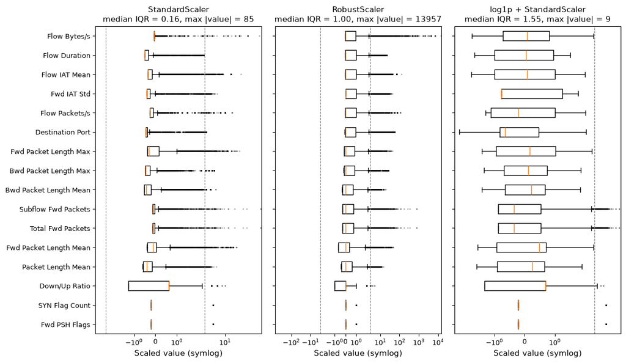

```
prepare_data applies log1p + StandardScaler, fitted on the training split only.
```

```python
# Compare three scalers. No model is trained: every option is fitted on the training set only.
X_train_raw = D["Xraw"]["train"]
feature_names = D["feature_names"]
assert (X_train_raw >= 0).all(), "log1p needs non-negative values"

# The three candidates map the same training data to different scales.
options = {
    "StandardScaler": StandardScaler().fit_transform(X_train_raw),
    "RobustScaler": RobustScaler().fit_transform(X_train_raw),
    "log1p + StandardScaler": StandardScaler().fit_transform(np.log1p(X_train_raw)),
}
# Features sorted by their maximum value.
order = pd.DataFrame(X_train_raw, columns=feature_names).max().sort_values().index

fig, axes = plt.subplots(1, 3, figsize=(12, 7), sharey=True)
# The dashed lines at +-3 mark the usual range after standardization.
for ax, (name, Z) in zip(axes, options.items()):
    Z_df = pd.DataFrame(Z, columns=feature_names)
    ax.boxplot([Z_df[c] for c in order], orientation="horizontal",
               flierprops=dict(marker=".", markersize=2, alpha=0.3))
    ax.axvline(-3, color="gray", linestyle="--", linewidth=0.8)
    ax.axvline(3, color="gray", linestyle="--", linewidth=0.8)
    ax.set_xscale("symlog")
    ax.set_xlabel("Scaled value (symlog)", fontsize=11)
    ax.tick_params(axis="x", labelsize=9)
    # Median IQR: width of the central 50% of the features after scaling.
    iqr = np.median(np.subtract(*np.percentile(Z, [75, 25], axis=0)))
    ax.set_title(f"{name}\nmedian IQR = {iqr:.2f}, max |value| = {np.abs(Z).max():.0f}",
                 fontsize=11)
axes[0].set_yticks(range(1, len(order) + 1))
axes[0].set_yticklabels(order, fontsize=9)
plt.tight_layout()
plt.show()
plt.close()

# Check that the lab uses exactly the third option.
assert np.allclose(D["X"]["train"], options["log1p + StandardScaler"])
print("prepare_data applies log1p + StandardScaler, fitted on the training split only.")
```

### 2.5. Chosen scaling: log1p + StandardScaler

*Q: Which scaling did you pick and why? How did the outliers inform the choice?*

`log1p` followed by `StandardScaler`. `StandardScaler` alone divides by the standard deviation, which is inflated by the extreme tails: the central 50% of the features ends up squeezed into a median IQR of 0.16 and the largest scaled value is 85, so the bulk of the samples collapses around zero and the network sees almost no variation in the range where 99% of the data lives. `RobustScaler` keeps the bulk at IQR = 1.00 and is therefore better, but it only rescales: the shape of the distribution does not change, so the tails still reach 13,957 in scaled units and a few extreme flows keep dominating the gradient. `log1p` attacks the cause: the features are counts, durations and rates with long right tails, and the logarithm makes them roughly symmetric, after which standardization leaves a usable dynamic range (median IQR 1.55, largest value 9 instead of $1.4 \cdot 10^4$).

The whole transform is fitted on the training set only and then applied to validation and test. `log1p` has no parameters to learn, so applying it to every partition causes no leakage; if the `StandardScaler` were fitted on the whole dataset, its mean and standard deviation would also depend on the test set and the test results would no longer be a fair estimate on unseen traffic. In `prepare_data` the two steps are wrapped in a single `Pipeline`, so the exact same transform is applied to any new array, e.g. the counterfactual test set of Task 3.

## 3. Helper functions

To help us with the following experiments, we define a set of auxiliary utility functions: The model architecture and optimization setup are managed by `build_model` and `build_optimizer`, which dynamically construct multi-layer perceptrons with configurable hidden dimensions, activation functions, dropout rates, and batch normalization alongside AdamW or SGD optimizers. Data ingestion is handled by `make_loaders`, converting data splits into PyTorch DataLoader instances with deterministic seed generators. Model training is executed through `fit`, which manages the training loop, tracks training and validation loss and macro-F1 scores, applies early stopping, and restores the best model checkpoint. Finally, `run_experiment` unifies the entire execution workflow by applying hyperparameter overrides, computing class-balanced loss weights when required, evaluating models on the validation set, and visualizing loss and metric curves via `plot_run`.

1. `build_model`: Dynamically builds the neural network with your chosen hidden layers, activation functions, dropout, and batch normalization.
2. `build_optimizer`: Sets up the optimizer (like AdamW or SGD) using your learning rate, weight decay, and momentum settings.
3. `make_loaders`: Converts the data splits into PyTorch DataLoaders with deterministic seeds for repeatable batches.
4. `fit`: Manages the training loop, tracks losses and macro-F1 scores, applies early stopping, and keeps the best model weights.
5. `run_experiment`: Orchestrates the whole process by handling overrides, calculating class weights, training the model, and printing results.
6. `plot_run`: Draws the training and validation loss curves alongside the validation macro-F1 progress across epochs.

```python
# Network builder: for each hidden layer Linear -> [BatchNorm] -> activation -> [Dropout].
# The last Linear layer gives one score per class.
def build_model(n_in, n_out, hidden_sizes=(64,), activation="relu", dropout=0.0, batchnorm=False):
    acts = {"relu": nn.ReLU, "linear": nn.Identity}
    layers, prev = [], n_in
    for h in hidden_sizes:
        layers.append(nn.Linear(prev, h))
        if batchnorm: layers.append(nn.BatchNorm1d(h))
        layers.append(acts[activation]())
        if dropout > 0: layers.append(nn.Dropout(dropout))
        prev = h
    layers.append(nn.Linear(prev, n_out))
    return nn.Sequential(*layers)

# Optimizer chosen by name. Both optimizers receive the weight decay.
def build_optimizer(params, name, lr, weight_decay, momentum):
    if name == "adamw": return optim.AdamW(params, lr=lr, weight_decay=weight_decay)
    if name == "sgd":   return optim.SGD(params, lr=lr, momentum=momentum, weight_decay=weight_decay)
    raise ValueError(name)

def make_loaders(data, scale, batch_size, seed):
    # Use the scaled features or the raw ones.
    X = data["X"] if scale else data["Xraw"]
    mk = lambda s: TensorDataset(torch.tensor(X[s], dtype=torch.float32),
                                 torch.tensor(data["y"][s], dtype=torch.long))
    # Fixed seed: the batches are the same at every run.
    # Validation is never shuffled and uses a bigger batch.
    g = torch.Generator().manual_seed(seed)
    return (DataLoader(mk("train"), batch_size=batch_size, shuffle=True, generator=g),
            DataLoader(mk("val"), batch_size=1024, shuffle=False))

# Loss and predictions on a whole split, without updating the weights.
def evaluate(model, loader, criterion):
    model.eval(); loss_sum, preds, labs = 0.0, [], []
    with torch.no_grad():
        for x, y in loader:
            x, y = x.to(device), y.to(device)
            out = model(x)
            loss_sum += criterion(out, y).item() * x.size(0)
            preds.append(out.argmax(1).cpu().numpy()); labs.append(y.cpu().numpy())
    return loss_sum / len(loader.dataset), np.concatenate(labs), np.concatenate(preds)

# Training loop with early stopping on the validation loss.
def fit(model, train_loader, val_loader, criterion, optimizer, epochs, patience, min_delta, restore_best=True):
    h = dict(train_loss=[], val_loss=[], val_f1=[])
    best, best_state, best_epoch, wait, t0 = float("inf"), None, 0, 0, time.time()
    for ep in range(epochs):
        model.train(); run = 0.0
        for x, y in train_loader:
            x, y = x.to(device), y.to(device)
            optimizer.zero_grad()
            loss = criterion(model(x), y)
            loss.backward(); optimizer.step()
            run += loss.item() * x.size(0)
        h["train_loss"].append(run / len(train_loader.dataset))
        vl, vt, vp = evaluate(model, val_loader, criterion)
        h["val_loss"].append(vl)
        h["val_f1"].append(f1_score(vt, vp, average="macro", zero_division=0))
        # Improvement: keep a copy of the weights on the CPU (cheaper than the GPU).
        if vl < best - min_delta:
            best, best_epoch, wait = vl, ep, 0
            best_state = {k: v.detach().cpu().clone() for k, v in model.state_dict().items()}
        else:
            wait += 1
            if wait >= patience: break
    # Put back the weights of the best epoch.
    if restore_best and best_state is not None: model.load_state_dict(best_state)
    h.update(best_epoch=best_epoch, n_epochs=len(h["train_loss"]), time_s=time.time() - t0)
    return h

# Default configuration. run_experiment can override any of these values.
DEFAULTS = dict(scale=True, hidden_sizes=(64,), activation="relu", dropout=0.0, batchnorm=False,
                optimizer="adamw", lr=5e-4, weight_decay=0.01, momentum=0.0,
                batch_size=64, epochs=100, patience=10, min_delta=1e-5,
                class_weight=None, seed=SEED, restore_best=True)

def run_experiment(task, change, data=None, plot=True, **overrides):
    """Run one experiment: build, train, evaluate and plot."""
    # Reject unknown parameter names, so a typo does not pass silently.
    unknown = set(overrides) - set(DEFAULTS)
    assert not unknown, f"unknown parameters: {unknown}"
    # Defaults + overrides = configuration of this run.
    cfg = {**DEFAULTS, **overrides}
    data = data or D
    names, n_cls = data["class_names"], len(data["class_names"])

    set_seed(cfg["seed"])
    tr, va = make_loaders(data, cfg["scale"], cfg["batch_size"], cfg["seed"])
    n_in = next(iter(tr))[0].shape[1]
    model = build_model(n_in, n_cls, cfg["hidden_sizes"], cfg["activation"],
                        cfg["dropout"], cfg["batchnorm"]).to(device)
    # Balanced loss: the rare classes get a bigger weight.
    w = None
    if cfg["class_weight"] == "balanced":
        c = np.bincount(data["y"]["train"], minlength=n_cls)
        w = torch.tensor(len(data["y"]["train"]) / (n_cls * c), dtype=torch.float32).to(device)
    criterion = nn.CrossEntropyLoss(weight=w)
    opt = build_optimizer(model.parameters(), cfg["optimizer"], cfg["lr"],
                          cfg["weight_decay"], cfg["momentum"])

    # Train the model.
    h = fit(model, tr, va, criterion, opt, cfg["epochs"], cfg["patience"], cfg["min_delta"], cfg["restore_best"])

    vl, vt, vp = evaluate(model, va, nn.CrossEntropyLoss())

    # Per-class report and confusion matrix on the validation split.
    print(f"=== {task} | {change} ===")

    report_dict = classification_report(vt, vp, target_names=names, digits=3, zero_division=0, output_dict=True)
    accuracy_val = report_dict.pop("accuracy")

    print(f"Overall Accuracy: {accuracy_val:.3f}\n")
    report_df = pd.DataFrame(report_dict).T.round(3)
    display(report_df)

    fig, ax = plt.subplots(figsize=(5.5, 4.5))
    cm = confusion_matrix(vt, vp)
    disp = ConfusionMatrixDisplay(confusion_matrix=cm, display_labels=names)
    disp.plot(ax=ax, cmap="Blues", values_format="d")
    plt.title(f"Confusion Matrix - {task}")
    plt.grid(False)
    plt.show()

    # Best epoch is stored 0-based; the printout and the plots use it as an index.
    print(f"Best epoch: {h['best_epoch'] + 1} | epochs run: {h['n_epochs']} | time: {h['time_s']:.1f} s")

    # Loss and macro-F1 curves.
    if plot:
        plot_run(h, f"{task}\n{change}")

    return dict(model=model, hist=h, cfg=cfg, y_true=vt, y_pred=vp)

# Two plots: loss (train vs validation) and macro-F1 on validation.
def plot_run(h, title, logy=False):
    fig, ax = plt.subplots(1, 2, figsize=(13, 4.2))
    ax[0].plot(h["train_loss"], label="Train"); ax[0].plot(h["val_loss"], label="Val")
    ax[0].axvline(h["best_epoch"], ls="--", color="gray", label="Best epoch")
    ax[0].set(xlabel="Epoch", ylabel="Loss", title=title); ax[0].legend(); ax[0].grid(alpha=.3)
    if logy: ax[0].set_yscale("log")
    ax[1].plot(h["val_f1"], color="green"); ax[1].axvline(h["best_epoch"], ls="--", color="gray")
    ax[1].set(xlabel="Epoch", ylabel="Macro-F1 (val)", title="Macro-F1 validation"); ax[1].grid(alpha=.3)
    plt.tight_layout(); plt.show()
```

## 4. Task 2

In this task, we test our framework with very simple examples. We mainly use the `run_experiment` function for this and future tasks.

### 4.1. Task 2A

In this task, we try our first simple baseline. This baseline is described by the default configuration of the `run_experiment` function

```
=== Task 2A | baseline: 1x64, ReLU, AdamW lr=5e-4, batch 64 ===
Overall Accuracy: 0.992
```

|  | precision | recall | f1-score | support |
| --- | --- | --- | --- | --- |
| Benign | 0.999 | 0.990 | 0.994 | 2886.0 |
| Brute Force | 0.914 | 0.995 | 0.953 | 214.0 |
| DoS Hulk | 0.980 | 0.997 | 0.988 | 580.0 |
| PortScan | 0.999 | 0.996 | 0.997 | 728.0 |
| macro avg | 0.973 | 0.994 | 0.983 | 4408.0 |
| weighted avg | 0.992 | 0.992 | 0.992 | 4408.0 |

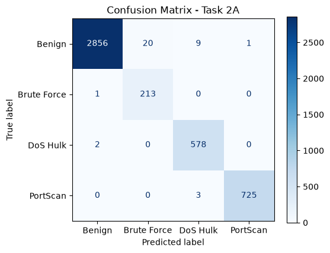

```
Best epoch: 96 | epochs run: 100 | time: 25.8 s
```

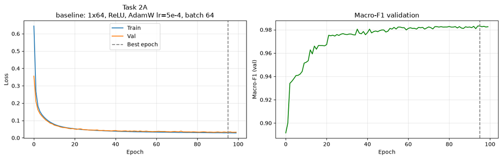

```python
r1 = run_experiment("Task 2A", "baseline: 1x64, ReLU, AdamW lr=5e-4, batch 64")
```

*Q: How do you pick the "best" model across epochs? Do the curves converge?*

Best model = lowest validation loss, checked every epoch, patience 10, best weights restored. Yes: both curves fall and flatten; the best epoch is 96 of 100, with validation loss 0.027, accuracy 0.992 and macro-F1 0.983.

*Q: Do your hardest-class predictions hold up? Explain the per-class results.*

Prediction: Brute Force (4.9% of the flows) would be the hardest. Only partly: its F1 is the lowest (0.953) but its recall is 0.995 and its precision 0.914, so the model misses almost no Brute Force flow; it pays for that with false positives (precision 0.914) on flows that look like Brute Force. Benign has the lowest recall (0.990) for the same reason: 10.5% of the Benign flows also use port 80. The network is using the port as a shortcut, which Task 3 tests directly.

### 4.2. Task 2B

Each run of this subtask will implement a different wrong way to modify the model, as specified in the lab document

First, we remove feature scaling

```
=== Task 2B | S1: no scaling ===
Overall Accuracy: 0.953
```

|  | precision | recall | f1-score | support |
| --- | --- | --- | --- | --- |
| Benign | 0.970 | 0.962 | 0.966 | 2886.0 |
| Brute Force | 0.856 | 0.836 | 0.846 | 214.0 |
| DoS Hulk | 0.879 | 0.898 | 0.888 | 580.0 |
| PortScan | 0.973 | 0.996 | 0.984 | 728.0 |
| macro avg | 0.920 | 0.923 | 0.921 | 4408.0 |
| weighted avg | 0.953 | 0.953 | 0.953 | 4408.0 |

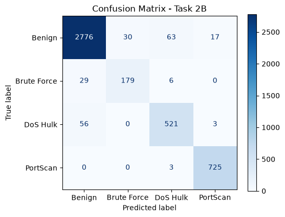

```
Best epoch: 46 | epochs run: 56 | time: 13.8 s
```

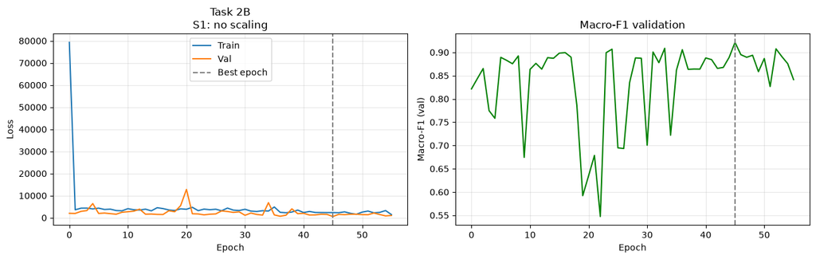

```python
r2 = run_experiment("Task 2B", "S1: no scaling", scale=False)
```

Then, we increase the learning rate

```
=== Task 2B | S2: lr 5e-4 -> 0.5 ===
Overall Accuracy: 0.953
```

|  | precision | recall | f1-score | support |
| --- | --- | --- | --- | --- |
| Benign | 0.960 | 0.970 | 0.965 | 2886.0 |
| Brute Force | 0.713 | 0.836 | 0.770 | 214.0 |
| DoS Hulk | 0.986 | 0.855 | 0.916 | 580.0 |
| PortScan | 0.981 | 0.995 | 0.988 | 728.0 |
| macro avg | 0.910 | 0.914 | 0.910 | 4408.0 |
| weighted avg | 0.955 | 0.953 | 0.953 | 4408.0 |

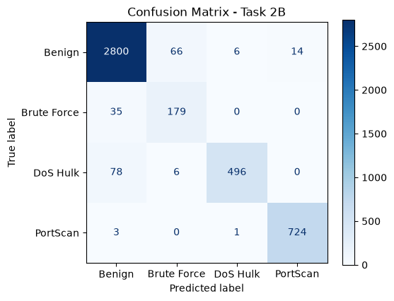

```
Best epoch: 5 | epochs run: 15 | time: 3.8 s
```

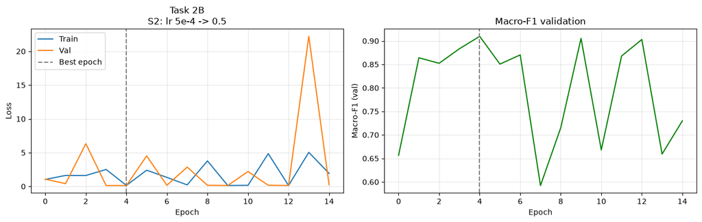

```python
r3 = run_experiment("Task 2B", "S2: lr 5e-4 -> 0.5", lr=0.5)
```

Finally, we try the opposite: we lower the learning rate

```
=== Task 2B | S3: lr 5e-4 -> 5e-6 (/100) ===
Overall Accuracy: 0.933
```

|  | precision | recall | f1-score | support |
| --- | --- | --- | --- | --- |
| Benign | 0.944 | 0.957 | 0.951 | 2886.0 |
| Brute Force | 0.792 | 0.836 | 0.814 | 214.0 |
| DoS Hulk | 0.976 | 0.772 | 0.862 | 580.0 |
| PortScan | 0.905 | 0.992 | 0.946 | 728.0 |
| macro avg | 0.904 | 0.889 | 0.893 | 4408.0 |
| weighted avg | 0.935 | 0.933 | 0.932 | 4408.0 |

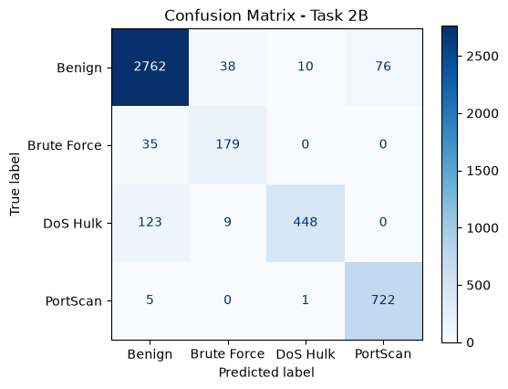

```
Best epoch: 100 | epochs run: 100 | time: 25.9 s
```

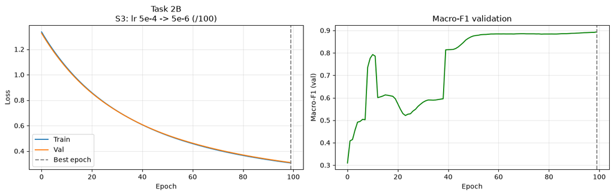

```python
r4 = run_experiment("Task 2B", "S3: lr 5e-4 -> 5e-6 (/100)", lr=5e-6)
```

*Q: Rank S1 to S3 by how badly they hurt, and which fundamental would you fix first on a new problem?*

Validation macro-F1: S3 (lr 5e-6) 0.893 < S2 (lr 0.5) 0.910 < S1 (no scaling) 0.921, against 0.983 for the baseline. The gaps between the three runs (0.011 to 0.028) are below the noise threshold of 0.05 (explained below), so the ranking is not established. What is solid is that every failure hurts by more than 0.06. Brute Force F1 does not follow the same order: S2 is the worst (0.770), then S3 (0.814) and S1 (0.846). Brute Force recall is 0.836 in S1, S2 and S3 and also in the linear model of Task 2C; this is not a logging error: the check cell after `r6` shows that the same 35 of the 214 Brute Force flows are missed in all four runs.

The data do not say that scaling is the most harmful failure: S1 is the least harmful in macro-F1 and in Brute Force F1. We would still fix scaling first, for reasons that macro-F1 hides. Without scaling the loss never gets close to the minimum (it stays in the thousands, against 0.03 for the baseline) and the validation macro-F1 swings between 0.55 and 0.92 from one epoch to the next. AdamW rescales the step of every parameter, so we expect it to hide part of the damage; we did not test another optimizer. Scaling is also a property of the data that no learning rate can compensate, and it costs one line, while the learning rate needs a sweep but its failures (S2, S3) are visible at once in the loss curve.

**Noise threshold.** Every run uses one seed, and validation holds only 43 PortScan flows once the port is removed. We treat a difference in validation macro-F1 below 0.05 as noise, in every comparison of the lab. Counting flows does not give this value (one PortScan flow moves macro-F1 by about 0.003); it comes from two measurements: the same notebook with the same seeds, executed on a CPU instead of the GPU, moved the macro-F1 of single runs by up to 0.042 (r3: 0.910 on GPU, 0.952 on CPU; r16: 0.817 and 0.782), and the validation macro-F1 of `r19` jumps by up to about 0.07 between two consecutive epochs.

### 4.3. Task 2C

In this task we train the model again by increasing its epochs, allowing it to converge better. We set this new model as our baseline

```
=== Task 2C | baseline: epochs 100 -> 300 ===
Overall Accuracy: 0.992
```

|  | precision | recall | f1-score | support |
| --- | --- | --- | --- | --- |
| Benign | 0.999 | 0.990 | 0.994 | 2886.0 |
| Brute Force | 0.914 | 0.995 | 0.953 | 214.0 |
| DoS Hulk | 0.980 | 0.998 | 0.989 | 580.0 |
| PortScan | 0.999 | 0.996 | 0.997 | 728.0 |
| macro avg | 0.973 | 0.995 | 0.983 | 4408.0 |
| weighted avg | 0.992 | 0.992 | 0.992 | 4408.0 |

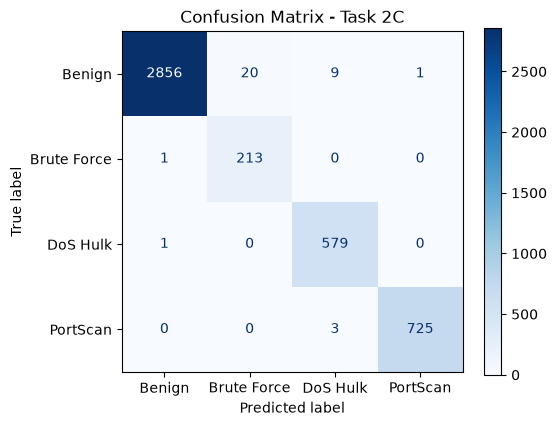

```
Best epoch: 156 | epochs run: 166 | time: 44.3 s
```

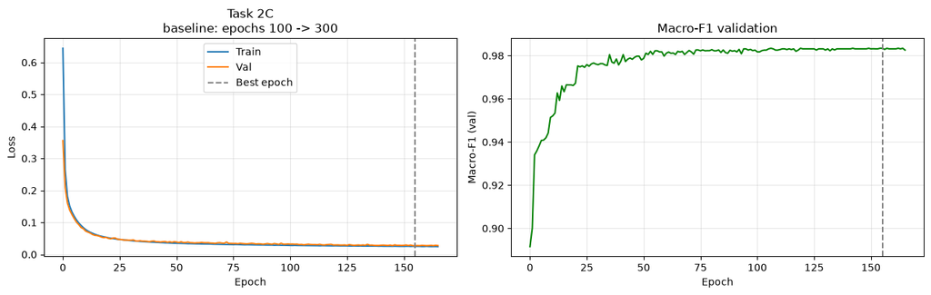

```python
r5 = run_experiment("Task 2C", "baseline: epochs 100 -> 300", epochs=300)
# The 300-epoch model is the base for the next tests.
BASE = r5
```

To evaluate the performance of the new model on the test set, we define a new function `eval_split`, that specifically evaluates the model on the validation or test split without training.

```python
def eval_split(model, data, split="test", scale=True, verbose=True):
    # Pick the requested split, scaled or raw.
    X = (data["X"] if scale else data["Xraw"])[split]
    y = data["y"][split]
    ds = TensorDataset(torch.tensor(X, dtype=torch.float32), torch.tensor(y, dtype=torch.long))
    # Loss, true labels and predictions for the whole split.
    loss, yt, yp = evaluate(model, DataLoader(ds, batch_size=1024, shuffle=False),
                            nn.CrossEntropyLoss())
    names = data["class_names"]
    # Print the per-class table and the confusion matrix.
    if verbose:
        print(f"--- {split.upper()} (loss {loss:.4f}) ---")
        report_dict = classification_report(yt, yp, target_names=names, digits=3, zero_division=0, output_dict=True)
        report_df = pd.DataFrame(report_dict).T
        report_df.index.name = None
        display(report_df.round(3))

        cm = confusion_matrix(yt, yp)
        cmd = ConfusionMatrixDisplay(confusion_matrix=cm, display_labels=names)
        cmd.plot(cmap="Blues", xticks_rotation="vertical")
        plt.show()

    # Numbers used to compare the models.
    return dict(
        loss=loss,
        macro_f1=f1_score(yt, yp, average="macro"),
        recall=recall_score(yt, yp, average=None, labels=range(len(names)), zero_division=0)
    )
```

We then ran the evaluation on the validation set and the test set, filling the performance gap. A minimal performance gap confirms that the model generalizes well to unseen network traffic and has not overfitted to the validation set.

```
--- VAL (loss 0.0273) ---
```

|  | precision | recall | f1-score | support |
| --- | --- | --- | --- | --- |
| Benign | 0.999 | 0.990 | 0.994 | 2886.000 |
| Brute Force | 0.914 | 0.995 | 0.953 | 214.000 |
| DoS Hulk | 0.980 | 0.998 | 0.989 | 580.000 |
| PortScan | 0.999 | 0.996 | 0.997 | 728.000 |
| accuracy | 0.992 | 0.992 | 0.992 | 0.992 |
| macro avg | 0.973 | 0.995 | 0.983 | 4408.000 |
| weighted avg | 0.992 | 0.992 | 0.992 | 4408.000 |

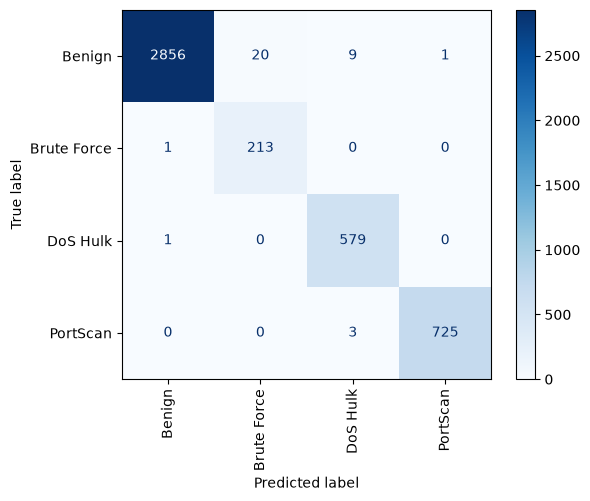

```
--- TEST (loss 0.0282) ---
```

|  | precision | recall | f1-score | support |
| --- | --- | --- | --- | --- |
| Benign | 0.999 | 0.989 | 0.994 | 2887.000 |
| Brute Force | 0.911 | 1.000 | 0.953 | 214.000 |
| DoS Hulk | 0.978 | 0.997 | 0.987 | 580.000 |
| PortScan | 0.999 | 0.997 | 0.998 | 727.000 |
| accuracy | 0.992 | 0.992 | 0.992 | 0.992 |
| macro avg | 0.972 | 0.996 | 0.983 | 4408.000 |
| weighted avg | 0.992 | 0.992 | 0.992 | 4408.000 |

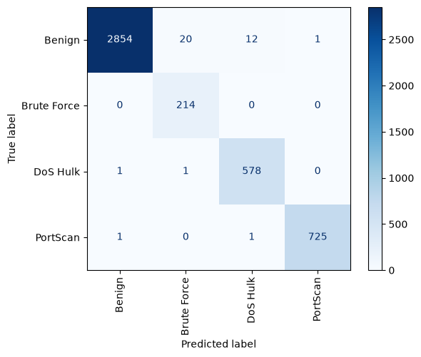

```
Comparison table
```

|  | val | test | gap |
| --- | --- | --- | --- |
| loss | 0.0273 | 0.0282 | 0.0009 |
| macro_F1 | 0.9834 | 0.9831 | -0.0003 |
| recall_Benign | 0.9896 | 0.9886 | -0.0010 |
| recall_Brute Force | 0.9953 | 1.0000 | 0.0047 |
| recall_DoS Hulk | 0.9983 | 0.9966 | -0.0017 |
| recall_PortScan | 0.9959 | 0.9972 | 0.0013 |

```python
val_res = eval_split(BASE["model"], D, "val")

test_res = eval_split(BASE["model"], D, "test")

# Validation vs test: a large gap means the model does not generalize.
cmp = pd.DataFrame({
    "val": [val_res["loss"], val_res["macro_f1"], *val_res["recall"]],
    "test": [test_res["loss"], test_res["macro_f1"], *test_res["recall"]]
}, index=["loss", "macro_F1"] + [f"recall_{n}" for n in D["class_names"]]).round(4)

cmp["gap"] = (cmp["test"] - cmp["val"]).round(4)
cmp.index.name = None

print ("Comparison table")
display(cmp)
```

Since the gaps are negligible, we lock the new model `r5` as our new baseline. The extra 200 epochs bought nothing measurable: the 100-epoch run and the 300-epoch run both stop at 0.983 validation macro-F1, so the longer budget makes the baseline more stable, not more accurate. Furthermore, we switch the activation function from ReLU to linear, as one controlled change on this baseline.

```
=== Task 2C | activation: ReLU -> linear ===
Overall Accuracy: 0.962
```

|  | precision | recall | f1-score | support |
| --- | --- | --- | --- | --- |
| Benign | 0.979 | 0.972 | 0.976 | 2886.0 |
| Brute Force | 0.762 | 0.836 | 0.797 | 214.0 |
| DoS Hulk | 0.924 | 0.921 | 0.922 | 580.0 |
| PortScan | 0.990 | 0.995 | 0.992 | 728.0 |
| macro avg | 0.914 | 0.931 | 0.922 | 4408.0 |
| weighted avg | 0.963 | 0.962 | 0.963 | 4408.0 |

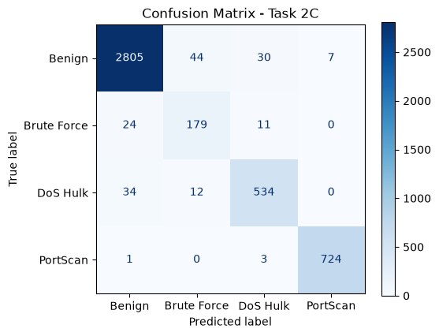

```
Best epoch: 93 | epochs run: 103 | time: 26.1 s
```

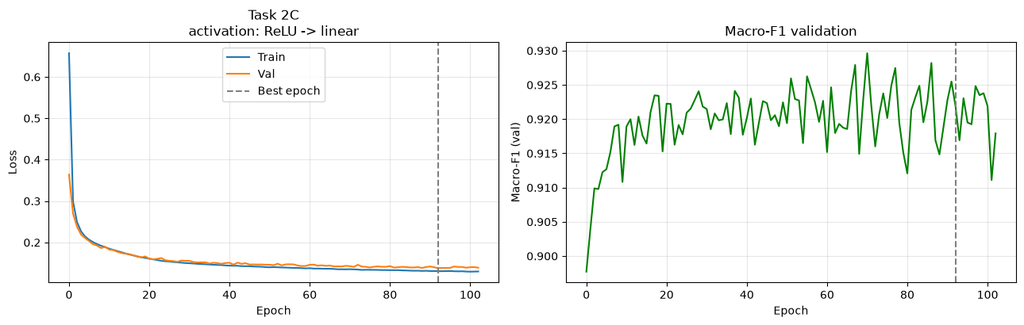

```python
# All Task 2C tests train for 300 epochs.
BASE_OVERRIDES = dict(epochs=300)

r6 = run_experiment("Task 2C", "activation: ReLU -> linear", activation="linear", **BASE_OVERRIDES)
```

Check: Brute Force recall is 0.836 in `r2`, `r3`, `r4` and `r6`. We list the Brute Force validation flows that each run misses and intersect them.

```python
bf = D["class_names"].index("Brute Force")
missed = {name: set(np.where((r["y_true"] == bf) & (r["y_pred"] != bf))[0])
          for name, r in [("r2", r2), ("r3", r3), ("r4", r4), ("r6", r6)]}
print({name: len(m) for name, m in missed.items()}, "of", int((r2["y_true"] == bf).sum()), "Brute Force flows")
print("Missed by all four runs:", len(set.intersection(*missed.values())))
```

```
{'r2': 35, 'r3': 35, 'r4': 35, 'r6': 35} of 214 Brute Force flows
Missed by all four runs: 35
```

*Q: Compare validation vs test. Does the model generalize?*

Yes: validation 0.992 accuracy / 0.983 macro-F1, test 0.992 / 0.983, with gaps of +0.0009 in loss and -0.0003 in macro-F1; Brute Force recall is 0.995 on validation and 1.000 on test. The 300-epoch baseline is not overfitted to validation. The extra 200 epochs, however, bought nothing: the 100-epoch run already reached the same 0.983.

*Q: Does the activation change the per-class results? Would it be fair to compare ReLU and linear on the test set?*

Yes: switching from ReLU to linear drops macro-F1 from 0.983 to 0.922, Brute Force F1 from 0.953 to 0.797 (recall 0.995 -> 0.836) and DoS Hulk from 0.989 to 0.922, so the non-linearity mainly helps the two port-80 attack classes. Choosing the winner on the test set would not be fair: the test set must stay untouched until the model is fixed, otherwise the reported score has already been used to select the model.

## 5. Task 3

The objective of this section is to determine whether certain attack types (e.g., port scan) are strongly correlated with specific destination port numbers. Identifying this correlation reveals whether the model might heavily rely on port numbers rather than behavioral network traffic features and checks if the port distributions in the test set mirror those seen during training.

```python
# Check how the destination port relates to the classes.
port_idx = D["feature_names"].index("Destination Port")
names = D["class_names"]
bf = names.index("Brute Force")
Xtr_raw, ytr = D["Xraw"]["train"], D["y"]["train"]

# Top 3 ports of each class in the training set.
for c, n in enumerate(names):
    p = Xtr_raw[ytr == c, port_idx]
    top = pd.Series(p).value_counts(normalize=True).head(3).round(3).to_dict()
    print(f"{n:12s} n={len(p):5d} | % on port 80 = {np.mean(p == 80):.3f} | top ports: {top}")

# Benign flows on ports 80 and 8080.
ben = names.index("Benign")
print("Benign on port 80:", int((Xtr_raw[ytr == ben, port_idx] == 80).sum()),
      "| on port 8080:", int((Xtr_raw[ytr == ben, port_idx] == 8080).sum()))
# Ports used by Brute Force in the test set.
print("Brute Force ports in test set:", np.unique(D["Xraw"]["test"][D["y"]["test"] == bf, port_idx]))
```

```
Benign       n=13467 | % on port 80 = 0.105 | top ports: {53.0: 0.428, 443.0: 0.233, 80.0: 0.105}
Brute Force  n=  999 | % on port 80 = 1.000 | top ports: {80.0: 1.0}
DoS Hulk     n= 2708 | % on port 80 = 1.000 | top ports: {80.0: 1.0}
PortScan     n= 3394 | % on port 80 = 0.001 | top ports: {5631.0: 0.003, 5440.0: 0.003, 2602.0: 0.003}
Benign on port 80: 1419 | on port 8080: 4
Brute Force ports in test set: [80.]
```

*Q: Is "Brute Force always on port 80" a property of brute-force attacks in general, or an artefact of this dataset? If the model sees this, what is it likely to learn?*

An artefact: 100% of the Brute Force training flows and 100% of DoS Hulk use port 80, while Benign uses it only 10.5% of the time; brute-force attacks also exist on SSH, FTP or RDP. The network will learn a shortcut ("port 80 means attack"), not the behaviour of the attack.

This next test modifies all Brute Force test samples targeting port 80 by reassigning them to port 8080, creating a modified version of our dataset

```python
# Counterfactual test: move the Brute Force flows from port 80 to port 8080.
Xte_cf = D["Xraw"]["test"].copy()
mask = (D["y"]["test"] == bf) & (Xte_cf[:, port_idx] == 80)

print("BF samples shifted to 8080:", int(mask.sum()), "out of", int((D["y"]["test"] == bf).sum()))

Xte_cf[mask, port_idx] = 8080
# Apply the same transform used during training.
Xte_cf_scaled = D["scaler"].transform(Xte_cf)
```

```
BF samples shifted to 8080: 214 out of 214
```

We then define the `eval_arrays` function as a utility that evaluates a trained PyTorch model directly on arrays without manual tensor conversion. It displays clean per-class metric tables and plots the confusion matrix. With this function, we evaluate the model on the modified dataset, performing a counterfactual test

```
Evaluation Loss: 0.9032 | Accuracy: 0.943 | Macro F1: 0.736
```

|  | precision | recall | f1-score | support |
| --- | --- | --- | --- | --- |
| Benign | 0.930 | 0.989 | 0.958 | 2887.0 |
| Brute Force | 0.000 | 0.000 | 0.000 | 214.0 |
| DoS Hulk | 0.978 | 0.997 | 0.987 | 580.0 |
| PortScan | 0.999 | 0.997 | 0.998 | 727.0 |

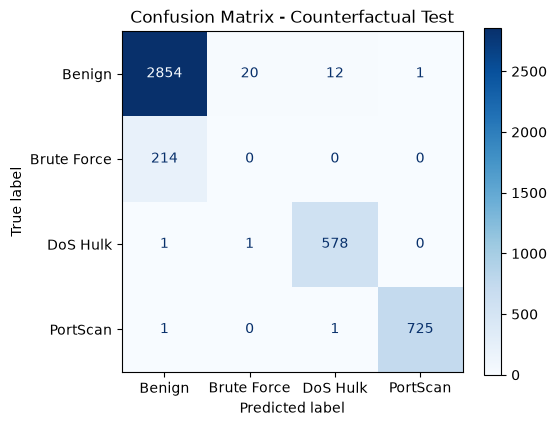

```python
# Same evaluation as eval_split, but on plain arrays.
def eval_arrays(model, X, y, names):
    ds = TensorDataset(torch.tensor(X, dtype=torch.float32), torch.tensor(y, dtype=torch.long))
    loss, yt, yp = evaluate(model, DataLoader(ds, batch_size=1024, shuffle=False), nn.CrossEntropyLoss())

    report_dict = classification_report(yt, yp, target_names=names, digits=3, zero_division=0, output_dict=True)
    acc = report_dict.pop("accuracy")
    macro_avg = report_dict.pop("macro avg")
    weighted_avg = report_dict.pop("weighted avg")

    # One line with the main numbers.
    print(f"Evaluation Loss: {loss:.4f} | Accuracy: {acc:.3f} | Macro F1: {macro_avg['f1-score']:.3f}\n")

    report_df = pd.DataFrame(report_dict).T.round(3)
    display(report_df)

    # Confusion matrix.
    fig, ax = plt.subplots(figsize=(5.5, 4.5))
    cm = confusion_matrix(yt, yp)
    disp = ConfusionMatrixDisplay(confusion_matrix=cm, display_labels=names)
    disp.plot(ax=ax, cmap="Blues", values_format="d")
    plt.title("Confusion Matrix - Counterfactual Test")
    plt.grid(False)
    plt.show()

    return yt, yp

yt, yp = eval_arrays(BASE["model"], Xte_cf_scaled, D["y"]["test"], names)
```

*Q: Did your prediction hold? What does this reveal about what the model was really using to detect Brute Force?*

Prediction: Brute Force recall would collapse. It held: recall 1.000 -> 0.000 (F1 0.000), accuracy 0.992 -> 0.943 and macro-F1 0.983 -> 0.736, only because 214 test flows moved from port 80 to 8080 with no retraining. The model was reading the destination port, not the traffic shape.

### 5.1. Dataset class distribution analysis

The code below details the class counts, sample proportions, and retention ratios for the modified dataset and puts them in comparison to the ones of the datasets across all stages of pre processing

```python
# Three versions of the data: with port, without port, without port and duplicates.
D_dup   = prepare_data(DATA_PATH, drop_port=True, drop_duplicates=False)
D_nodup = prepare_data(DATA_PATH, drop_port=True, drop_duplicates=True)

# Class counts in each version.
tab = pd.DataFrame({
    "raw":                  D["counts"]["raw"],
    "with port":    D["counts"]["after_clean"],
    "no port":    D_dup["counts"]["after_clean"],
    "no port + dedup":      D_nodup["counts"]["after_clean"]
})
tab.loc["TOTAL"] = tab.sum()
tab.index.name = None

print("Class Counts Across Preprocessing Pipeline:")
display(tab)

proportions_df = (tab / tab.loc["TOTAL"]).round(3)
print("\nClass Proportions:")
display(proportions_df)

# Share of rows lost when the port and the duplicates are removed.
retention_series = (1-tab["no port + dedup"] / tab["with port"]).round(3)
retention_df = retention_series.to_frame(name="Drop Ratio")
print("Variation")
display(retention_df)
```

```
Class Counts Across Preprocessing Pipeline:
```

|  | raw | with port | no port | no port + dedup |
| --- | --- | --- | --- | --- |
| Benign | 20000 | 19240 | 19990 | 16888 |
| Brute Force | 1507 | 1427 | 1507 | 1427 |
| DoS Hulk | 5000 | 3868 | 4982 | 3868 |
| PortScan | 5000 | 4849 | 4999 | 285 |
| TOTAL | 31507 | 29384 | 31478 | 22468 |

```
Class Proportions:
```

|  | raw | with port | no port | no port + dedup |
| --- | --- | --- | --- | --- |
| Benign | 0.635 | 0.655 | 0.635 | 0.752 |
| Brute Force | 0.048 | 0.049 | 0.048 | 0.064 |
| DoS Hulk | 0.159 | 0.132 | 0.158 | 0.172 |
| PortScan | 0.159 | 0.165 | 0.159 | 0.013 |
| TOTAL | 1.000 | 1.000 | 1.000 | 1.000 |

```
Variation
```

|  | Drop Ratio |
| --- | --- |
| Benign | 0.122 |
| Brute Force | 0.000 |
| DoS Hulk | 0.000 |
| PortScan | 0.941 |
| TOTAL | 0.235 |

*Q: Count the classes after cleaning now, and compare to before. Which class shrinks when the port is removed and duplicates are dropped, and by how much?*

With the port: 29384 flows (Benign 19240, Brute Force 1427, DoS Hulk 3868, PortScan 4849). Without port, de-duplicated: 22468 flows (Benign 16888, Brute Force 1427, DoS Hulk 3868, PortScan 285). PortScan loses 94.1% (4849 -> 285) and Benign 12.2%, while the other two classes do not move.

*Q: Why does that class collapse while the others barely move? What does that tell you about what the model "knew" about that class?*

A PortScan flow is one connection attempt per port: without the port, thousands of them become the same row and de-duplication keeps only 285. The other classes differ in volumes and timings, so their rows stay unique. Before, PortScan looked large and easy because it counted near-copies of the same behaviour.

We define `D2` as the sanitized dataset without the destination port feature and with deduplication applied. The dataset `D2` will be used for the rest of the lab

```python
D2 = D_nodup

classes = D2["class_names"]
# Number of samples per class in each split.
split_dist = pd.DataFrame({
    "Train": np.bincount(D2["y"]["train"], minlength=len(classes)),
    "Val":   np.bincount(D2["y"]["val"], minlength=len(classes)),
    "Test":  np.bincount(D2["y"]["test"], minlength=len(classes))
}, index=classes)

split_dist["Total"] = split_dist.sum(axis=1)
split_dist.loc["TOTAL"] = split_dist.sum(axis=0)
split_dist.index.name = None

print("Class Distribution Across Splits (D2):")
display(split_dist)
```

```
Class Distribution Across Splits (D2):
```

|  | Train | Val | Test | Total |
| --- | --- | --- | --- | --- |
| Benign | 11821 | 2533 | 2534 | 16888 |
| Brute Force | 999 | 214 | 214 | 1427 |
| DoS Hulk | 2708 | 580 | 580 | 3868 |
| PortScan | 199 | 43 | 43 | 285 |
| TOTAL | 15727 | 3370 | 3371 | 22468 |

*Q: After dropping the port, which class is now the rarest? How balanced is the data now?*

PortScan, with 285 flows (1.3%), against Brute Force 1427 (6.4%), DoS Hulk 3868 (17.2%) and Benign 16888 (75.2%). The imbalance is much worse than before removing the port, when the rarest class was 4.9%.

*Q: Knowing that de-duplication decimates one class once the port is gone, do you still de-duplicate?*

Yes. Duplicate rows are the same flow copied, not independent evidence: keeping them inflates the metrics and puts identical rows in train and test. We keep the 285 distinct PortScan flows and compensate with class weights in Task 4.

## 6. Task 4

The objective of this task is to see how the new dataset affects our model.

Firstly, we run our baseline using the new dataset `D2`

```
=== Task 4 | Baseline on dataset without Destination Port (D2) ===
Overall Accuracy: 0.982
```

|  | precision | recall | f1-score | support |
| --- | --- | --- | --- | --- |
| Benign | 0.986 | 0.990 | 0.988 | 2533.0 |
| Brute Force | 0.931 | 0.939 | 0.935 | 214.0 |
| DoS Hulk | 0.982 | 0.967 | 0.975 | 580.0 |
| PortScan | 0.975 | 0.907 | 0.940 | 43.0 |
| macro avg | 0.969 | 0.951 | 0.959 | 3370.0 |
| weighted avg | 0.982 | 0.982 | 0.982 | 3370.0 |

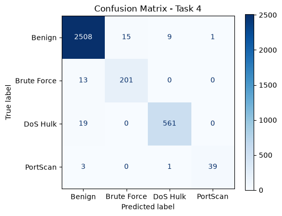

```
Best epoch: 167 | epochs run: 177 | time: 35.1 s
```

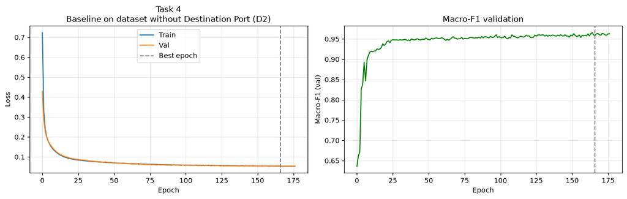

```python
r7 = run_experiment("Task 4", "Baseline on dataset without Destination Port (D2)", data=D2, **BASE_OVERRIDES)
```

*Q: Can you still detect the rarest class at all?*

Yes. On validation, without class weights: PortScan recall 0.907, precision 0.975, F1 0.940 (43 flows in validation, 199 in training), accuracy 0.982 and macro-F1 0.959. The class is rare but not lost, because its behaviour is still different from the other classes.

Caveat for all the numbers of Tasks 4 to 6: validation and test contain only 43 PortScan flows each, so one flow moves its recall by 2.3 points. For macro-F1 a single flow weighs little (about 0.003), so the noise threshold of 0.05 used in this lab comes from run-to-run variation (see Task 2B), not from counting flows. Differences below 0.05 are not reliable with a single seed. The loss of the port costs a nominal 0.024 macro-F1 (0.983 to 0.959), below that threshold.

Then, we change our loss function to a class-weighted cross-entropy loss (balanced weights) and train again.

```
=== 4B | Weighted Loss (balanced) ===
Overall Accuracy: 0.960
```

|  | precision | recall | f1-score | support |
| --- | --- | --- | --- | --- |
| Benign | 0.995 | 0.953 | 0.974 | 2533.0 |
| Brute Force | 0.834 | 0.986 | 0.904 | 214.0 |
| DoS Hulk | 0.924 | 0.979 | 0.951 | 580.0 |
| PortScan | 0.553 | 0.977 | 0.706 | 43.0 |
| macro avg | 0.826 | 0.974 | 0.884 | 3370.0 |
| weighted avg | 0.967 | 0.960 | 0.962 | 3370.0 |

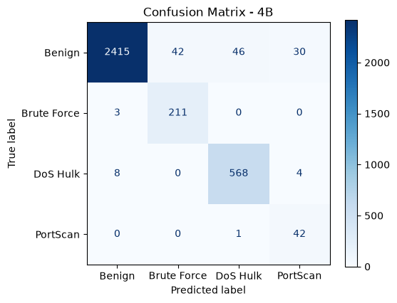

```
Best epoch: 81 | epochs run: 91 | time: 17.5 s
```

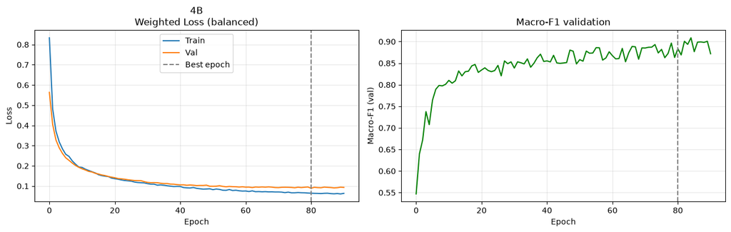

```python
r8 = run_experiment("4B", "Weighted Loss (balanced)", data=D2, class_weight="balanced", **BASE_OVERRIDES)
```

*Q: From which partition do you compute the class weights, and why would using another partition be wrong?*

From the training split of `D2` only (`np.bincount` on `data["y"]["train"]`, 15727 flows). Weights computed on validation or test would encode the evaluation distribution into the loss and bias the numbers used to judge the model.

*Q: Did accuracy and macro-F1 move in the same direction? Which metric should an intrusion detector optimize?*

Both fell: accuracy 0.982 -> 0.960 and macro-F1 0.959 -> 0.884, while rare-class recall rose (PortScan 0.907 -> 0.977, Brute Force 0.939 -> 0.986) and PortScan precision fell from 0.975 to 0.553. The weights therefore buy recall, not macro-F1: they trade many false alarms for few missed attacks. Accuracy is dominated by Benign (75%), so it is the wrong headline. For an intrusion detector rare-class recall is what matters most, but recall alone is maximised by flagging everything as an attack, so we select every model on validation macro-F1, which also penalises false alarms, and we report precision and recall of the rare classes next to it (R8 has the best PortScan recall and the worst macro-F1). The final output is an operating point chosen on the precision/recall curve, because a missed attack costs more than a false alarm.

## 7. Task 5

In this task, we evaluate if more complex models can beat our baseline.

We establish a new baseline. It maintains the exact model architecture and hyperparameters as the original setup, modified only by adjusting the loss function to handle class imbalance (it is the same model used in the last section of Task 4)

Parent of Tasks 5 and 6: R9 to R19 start from the weighted `r8`, the model Task 4 ends with, because the weights give the best rare-class recall (PortScan 0.977 against 0.907). By our selection criterion, validation macro-F1, `r7` would be the better parent: `r8` is 0.075 below it (0.884 against 0.959). This is a weakness of the design: every run of Task 5 inherits the weights of `r8`, so when a Task 5 model stays below `r7` the runs cannot say how much is the architecture and how much is the loss. We keep the parent because it is the model the lab asks to carry forward, and we read the differences inside Task 5 (one architecture at a time) rather than against `r7`.

```python
# Settings shared by all Task 5 experiments.
T5 = dict(class_weight="balanced", **BASE_OVERRIDES)
```

### 7.1. Task 5A

We train three models, each one with different hidden layer structures.

The first model has two hidden layers, of sizes `(64,32)`

```
=== 5A | Hidden Layers: (64,32) ===
Overall Accuracy: 0.963
```

|  | precision | recall | f1-score | support |
| --- | --- | --- | --- | --- |
| Benign | 0.996 | 0.957 | 0.976 | 2533.0 |
| Brute Force | 0.802 | 0.986 | 0.885 | 214.0 |
| DoS Hulk | 0.934 | 0.981 | 0.957 | 580.0 |
| PortScan | 0.656 | 0.977 | 0.785 | 43.0 |
| macro avg | 0.847 | 0.975 | 0.901 | 3370.0 |
| weighted avg | 0.969 | 0.963 | 0.965 | 3370.0 |

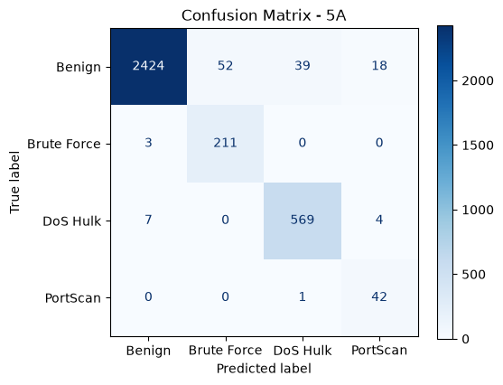

```
Best epoch: 32 | epochs run: 42 | time: 9.2 s
```

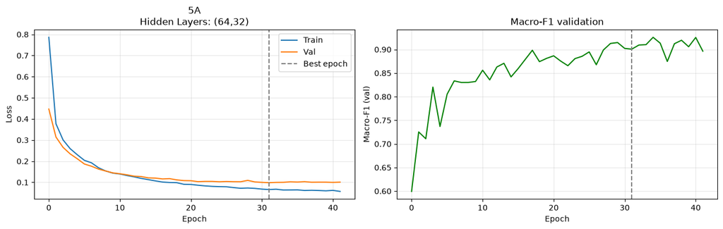

```python
r9 = run_experiment("5A", "Hidden Layers: (64,32)", data=D2, hidden_sizes=(64, 32), **T5)
```

The second has three hidden layers, of sizes `(64,32,16)`

```
=== 5A | Hidden Layers (64,32,16) ===
Overall Accuracy: 0.962
```

|  | precision | recall | f1-score | support |
| --- | --- | --- | --- | --- |
| Benign | 0.996 | 0.955 | 0.975 | 2533.0 |
| Brute Force | 0.808 | 0.986 | 0.888 | 214.0 |
| DoS Hulk | 0.928 | 0.981 | 0.954 | 580.0 |
| PortScan | 0.636 | 0.977 | 0.771 | 43.0 |
| macro avg | 0.842 | 0.975 | 0.897 | 3370.0 |
| weighted avg | 0.968 | 0.962 | 0.963 | 3370.0 |

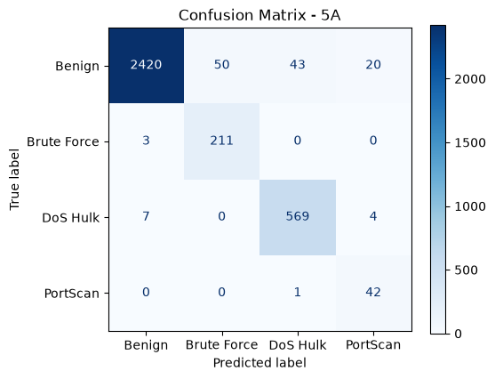

```
Best epoch: 33 | epochs run: 43 | time: 11.4 s
```

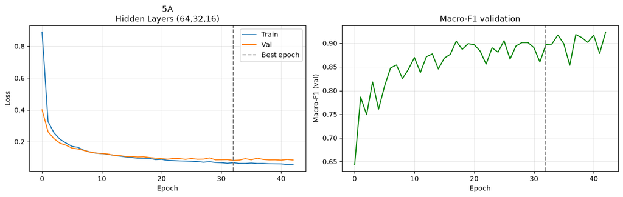

```python
r10 = run_experiment("5A", "Hidden Layers (64,32,16)", data=D2, hidden_sizes=(64, 32, 16), **T5)
```

The third one has three hidden layers, of sizes `(128,64,32)`

```
=== 5A | Hidden Layers (128,64,32) ===
Overall Accuracy: 0.969
```

|  | precision | recall | f1-score | support |
| --- | --- | --- | --- | --- |
| Benign | 0.998 | 0.963 | 0.980 | 2533.0 |
| Brute Force | 0.828 | 0.991 | 0.902 | 214.0 |
| DoS Hulk | 0.932 | 0.988 | 0.959 | 580.0 |
| PortScan | 0.764 | 0.977 | 0.857 | 43.0 |
| macro avg | 0.880 | 0.980 | 0.925 | 3370.0 |
| weighted avg | 0.973 | 0.969 | 0.970 | 3370.0 |

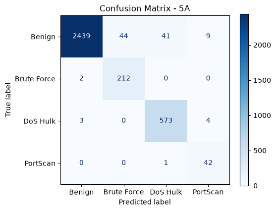

```
Best epoch: 22 | epochs run: 32 | time: 7.7 s
```

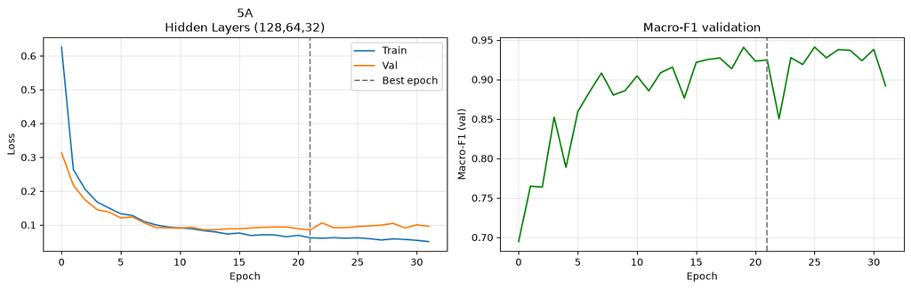

```python
r11 = run_experiment("5A", "Hidden Layers (128,64,32)", data=D2, hidden_sizes=(128, 64, 32), **T5)
```

*Q: Does depth help on this problem? If a single-hidden-layer baseline stays competitive, what does that suggest about the complexity of this task?*

Not measurably. With the weights fixed, one layer gives 0.884, two layers 0.901 (+0.017), three layers 0.897 (-0.004) and the wider (128,64,32) 0.925 (+0.028 over (64,32,16), +0.041 over one layer). All the differences are below the 0.05 noise threshold, so we cannot say that depth or width helps. None of the configurations reaches the unweighted single-layer baseline of Task 4 (0.959), but this comparison is confounded: every run here keeps the weighted loss, and the weighted baseline alone is already 0.075 below `r7`. Inside Task 5 the architecture adds nothing beyond noise, which suggests a low-dimensional, largely separable task in which a single hidden layer already has enough capacity. Whether a deeper network trained without the weights would match `r7` is the test we did not run.